# Prosper Loans Data Exploration

## Preliminary Wrangling

> This notebook explores a dataset of Prosper loans.

```python
# import all packages and set plots to be embedded inline
import numpy as np
import pandas as pd
import matplotlib.pyplot as plt
import seaborn as sb
from scipy import stats
%matplotlib inline
```

```python
#load the data
loans = pd.read_csv('prosperLoanData.csv')
```

```python
#view the data shape and features
print(loans.shape)
print(loans.dtypes)
print(loans.head(10))
```

```
(113937, 81)
ListingKey                      object
ListingNumber                    int64
ListingCreationDate             object
CreditGrade                     object
Term                             int64
                                ...
PercentFunded                  float64
Recommendations                  int64
InvestmentFromFriendsCount       int64
InvestmentFromFriendsAmount    float64
Investors                        int64
Length: 81, dtype: object
                ListingKey  ListingNumber            ListingCreationDate  \
0  1021339766868145413AB3B         193129  2007-08-26 19:09:29.263000000
```

[output cut: 71 more lines]

```python
loans = loans[['Term', 'LoanStatus','BorrowerAPR','BorrowerRate','LenderYield','EstimatedEffectiveYield'
,'EstimatedLoss','EstimatedReturn','IncomeRange'
,'Recommendations','Investors']]
```

```python
#view the data shape and features
print(loans.shape)
print(loans.dtypes)
print(loans.head(10))
```

```
(113937, 11)
Term                         int64
LoanStatus                  object
BorrowerAPR                float64
BorrowerRate               float64
LenderYield                float64
EstimatedEffectiveYield    float64
EstimatedLoss              float64
EstimatedReturn            float64
IncomeRange                 object
Recommendations              int64
Investors                    int64
dtype: object
   Term LoanStatus  BorrowerAPR  BorrowerRate  LenderYield  \
0    36  Completed      0.16516        0.1580       0.1380
1    36    Current      0.12016        0.0920       0.0820
2    36  Completed      0.28269        0.2750       0.2400
3    36    Current      0.12528        0.0974       0.0874
4    36    Current      0.24614        0.2085       0.1985
5    60    Current      0.15425        0.1314       0.1214
6    36    Current      0.31032        0.2712       0.2612
7    36    Current      0.23939        0.2019       0.1919
8    36    Current      0.07620        0.0629       0.0529
9    36    Current      0.07620        0.0629       0.0529

   EstimatedEffectiveYield  EstimatedLoss  EstimatedReturn     IncomeRange  \
0                      NaN            NaN              NaN  $25,000-49,999
1                  0.07960         0.0249          0.05470  $50,000-74,999
2                      NaN            NaN              NaN   Not displayed
3                  0.08490         0.0249          0.06000  $25,000-49,999
4                  0.18316         0.0925          0.09066       $100,000+
5                  0.11567         0.0449          0.07077       $100,000+
6                  0.23820         0.1275          0.11070  $25,000-49,999
7                  0.17830         0.0799          0.09840  $25,000-49,999
8                  0.05221         0.0099          0.04231  $25,000-49,999
9                  0.05221         0.0099          0.04231  $25,000-49,999

   Recommendations  Investors
0                0        258
1                0          1
2                0         41
3                0        158
4                0         20
5                0          1
6                0          1
7                0          1
8                0          1
9                0          1
```

```python
loans.info()
```

```
<class 'pandas.core.frame.DataFrame'>
RangeIndex: 113937 entries, 0 to 113936
Data columns (total 11 columns):
 #   Column                   Non-Null Count   Dtype
---  ------                   --------------   -----
 0   Term                     113937 non-null  int64
 1   LoanStatus               113937 non-null  object
 2   BorrowerAPR              113912 non-null  float64
 3   BorrowerRate             113937 non-null  float64
 4   LenderYield              113937 non-null  float64
 5   EstimatedEffectiveYield  84853 non-null   float64
 6   EstimatedLoss            84853 non-null   float64
 7   EstimatedReturn          84853 non-null   float64
 8   IncomeRange              113937 non-null  object
 9   Recommendations          113937 non-null  int64
 10  Investors                113937 non-null  int64
dtypes: float64(6), int64(3), object(2)
memory usage: 9.6+ MB
```

The data has a lot of null values that needs to be cleaned. Since the number of nulls is many, we can't just drop the null rows. We'll apply a mean interpolation to the missing features.

```python
loans['EstimatedEffectiveYield'].fillna(loans['EstimatedEffectiveYield'].mean(), inplace = True)
```

```python
loans['EstimatedLoss'].fillna(loans['EstimatedLoss'].mean(), inplace = True)
```

```python
loans['EstimatedReturn'].fillna(loans['EstimatedReturn'].mean(), inplace = True)
```

Then, To complete the cleaning process, we shall drop the duplicated rows.

```python
loans.drop_duplicates(inplace=True)
```

```python
loans.info()
```

```
<class 'pandas.core.frame.DataFrame'>
Int64Index: 83501 entries, 0 to 113935
Data columns (total 11 columns):
 #   Column                   Non-Null Count  Dtype
---  ------                   --------------  -----
 0   Term                     83501 non-null  int64
 1   LoanStatus               83501 non-null  object
 2   BorrowerAPR              83477 non-null  float64
 3   BorrowerRate             83501 non-null  float64
 4   LenderYield              83501 non-null  float64
 5   EstimatedEffectiveYield  83501 non-null  float64
 6   EstimatedLoss            83501 non-null  float64
 7   EstimatedReturn          83501 non-null  float64
 8   IncomeRange              83501 non-null  object
 9   Recommendations          83501 non-null  int64
 10  Investors                83501 non-null  int64
dtypes: float64(6), int64(3), object(2)
memory usage: 7.6+ MB
```

### What is/are the main feature(s) of interest in your dataset?

> The main interest is to figure out What factors affect a borrower's rate and APR.

### What features in the dataset do you think will help support your investigation into your feature(s) of interest?

> The Term and Estimated Retrun.

## Univariate Exploration

First we will start with plotting the distribution of the variables of interest.

```python
base_color = sb.color_palette()[0];
```

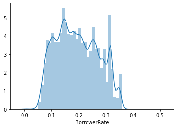

```python
sb.distplot(loans['BorrowerRate'], kde = True);
```

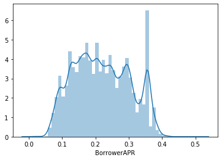

```python
sb.distplot(loans['BorrowerAPR'], kde = True)
```

Borrowers' Rate and APR have a normal like distribution with high kernel density towards the tails of the distribution.

Second, we will navigate the other features in the data set to see their distributions and trends.

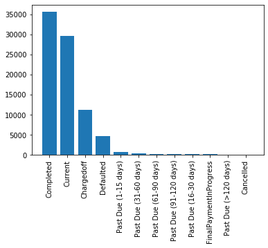

```python
pltData = loans['LoanStatus'].value_counts()
plt.bar(pltData.index, pltData)
plt.xticks(rotation = 90);
```

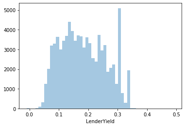

```python
sb.distplot(loans['LenderYield'], kde = False)
```

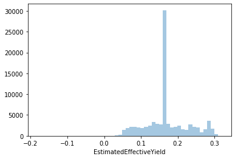

```python
sb.distplot(loans['EstimatedEffectiveYield'], kde = False)
```

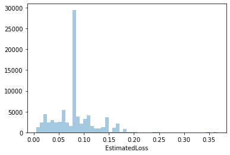

```python
sb.distplot(loans['EstimatedLoss'], kde = False)
```

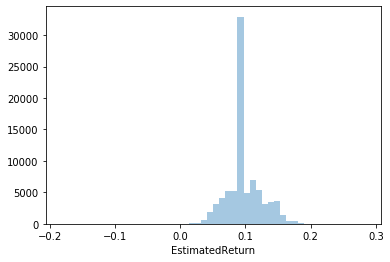

```python
sb.distplot(loans['EstimatedReturn'], kde = False)
```

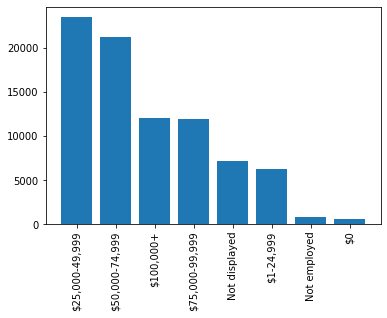

```python
pltData = loans['IncomeRange'].value_counts()
plt.bar(pltData.index, pltData)
plt.xticks(rotation = 90);
```

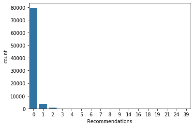

```python
sb.countplot(loans['Recommendations'], color = base_color);
```

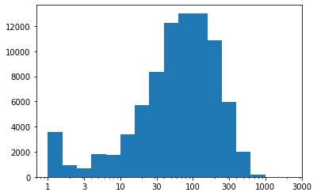

```python
bins = 10**np.arange(0, np.log10(loans['Investors'].max())+0.2, 0.2);
plt.hist(loans['Investors'], bins = bins);
ticks = np.arange(0, np.log10(loans['Investors'].max())+0.5, 0.5);
plt.xscale('log');
labels = [1, 3, 10, 30, 100, 300, 1000, 3000]
plt.xticks(10**ticks, labels);
```

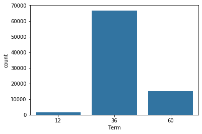

```python
sb.countplot(loans['Term'], color = base_color);
```

### General Comments:

- Most of the distribution is normal with some values that has relatively high frequencies.
- In "Term" feature it's appeared that 36 is the most common term followed by 60 then 12.
- '0' recommendations is the most common value.

### Discuss the distribution(s) of your variable(s) of interest. Were there any unusual points? Did you need to perform any transformations?

> The distibution is normal with high frequency of high-valued points towards the tail of the distibution.

### Of the features you investigated, were there any unusual distributions? Did you perform any operations on the data to tidy, adjust, or change the form of the data? If so, why did you do this?

> The "Investors" feature was significantly skewed so "log" transformation was used to see the distribution among the data.

## Bivariate Exploration

> First thing we shall generate the scatter matrix to spot quick relations in the data to help further investigation.

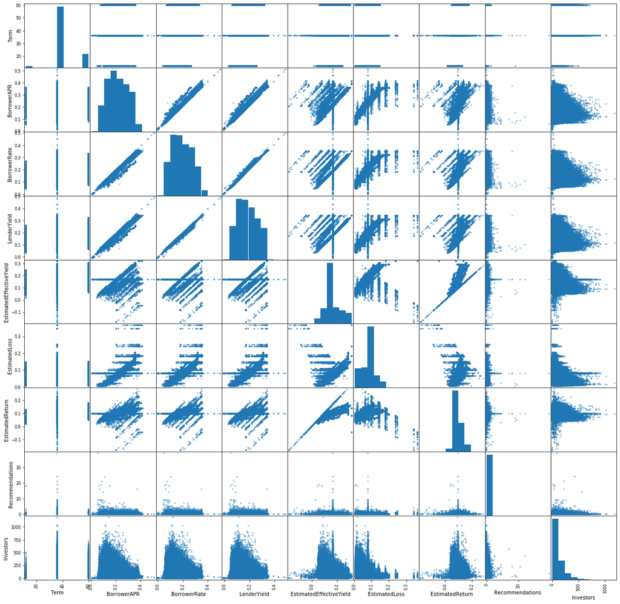

```python
pd.plotting.scatter_matrix(loans,figsize = [21,21]);
```

After having a quick look on the relations between the features, we will start plotting the relation between the categorical features and the features of interest: BorrowerRate and BorrowerAPR.

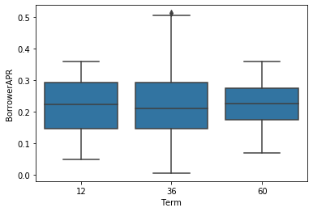

```python
sb.boxplot(data = loans, x = 'Term', y = 'BorrowerAPR', color = base_color);
```

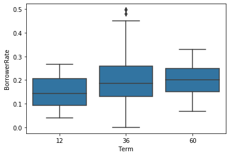

```python
sb.boxplot(data = loans, x = 'Term', y = 'BorrowerRate', color = base_color);
```

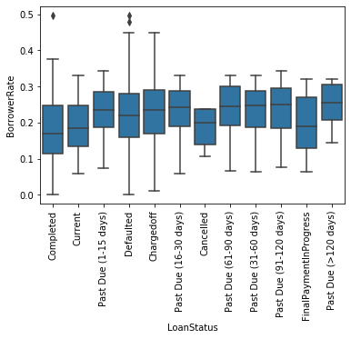

```python
sb.boxplot(data = loans, x = 'LoanStatus', y = 'BorrowerRate', color = base_color);
plt.xticks(rotation = 90);
```

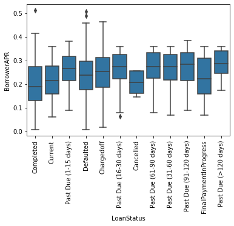

```python
sb.boxplot(data = loans, x = 'LoanStatus', y = 'BorrowerAPR', color = base_color);
plt.xticks(rotation = 90);
```

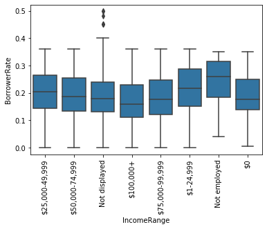

```python
sb.boxplot(data = loans, x = 'IncomeRange', y = 'BorrowerRate', color = base_color);
plt.xticks(rotation = 90);
```

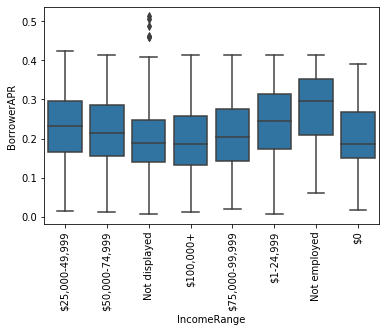

```python
sb.boxplot(data = loans, x = 'IncomeRange', y = 'BorrowerAPR', color = base_color);
plt.xticks(rotation = 90);
```

Also, discovering relations between categorical variables and other features along the way.

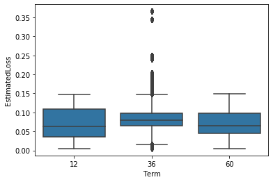

```python
sb.boxplot(data = loans, x = 'Term', y = 'EstimatedLoss', color = base_color);
```

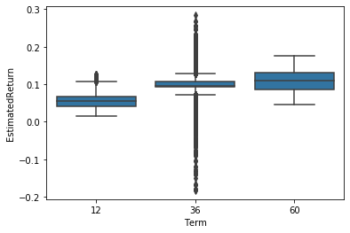

```python
sb.boxplot(data = loans, x = 'Term', y = 'EstimatedReturn', color = base_color);
```

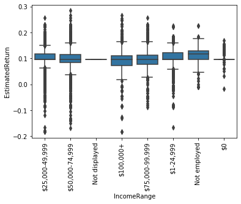

```python
sb.boxplot(data = loans, x = 'IncomeRange', y = 'EstimatedReturn', color = base_color);
plt.xticks(rotation = 90);
```

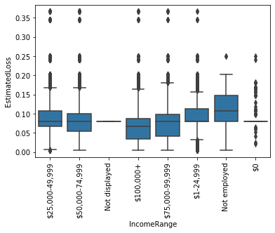

```python
sb.boxplot(data = loans, x = 'IncomeRange', y = 'EstimatedLoss', color = base_color);
plt.xticks(rotation = 90);
```

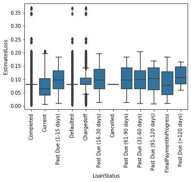

```python
sb.boxplot(data = loans, x = 'LoanStatus', y = 'EstimatedLoss', color = base_color);
plt.xticks(rotation = 90);
```

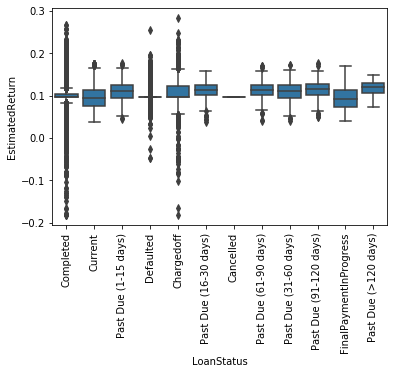

```python
sb.boxplot(data = loans, x = 'LoanStatus', y = 'EstimatedReturn', color = base_color);
plt.xticks(rotation = 90);
```

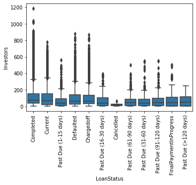

```python
sb.boxplot(data = loans, x = 'LoanStatus', y = 'Investors', color = base_color);
plt.xticks(rotation = 90);
```

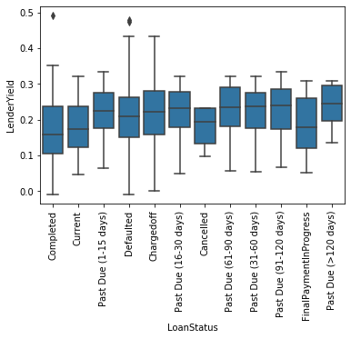

```python
sb.boxplot(data = loans, x = 'LoanStatus', y = 'LenderYield', color = base_color);
plt.xticks(rotation = 90);
```

### Talk about some of the relationships you observed in this part of the investigation. How did the feature(s) of interest vary with other features in the dataset?

- As the term increases from 12 to 35 to 60, the borrower rate also increases.
- BorrowerRate and BorrowerAPR has a positive corelating with variable strength with the following variables: (LenderYield, EstimatedEffectiveYield, EstimatedLoss, EstimatedReturn)

## Multivariate Exploration

> In this part, we shall explore more relation between more than one feature

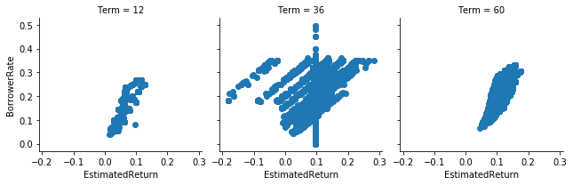

```python
g = sb.FacetGrid(data = loans, col = 'Term', height = 3,
                margin_titles = True)
g.map(plt.scatter, 'EstimatedReturn', 'BorrowerRate');
```

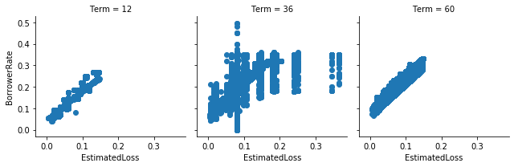

```python
g = sb.FacetGrid(data = loans, col = 'Term', height = 3,
                margin_titles = True)
g.map(plt.scatter, 'EstimatedLoss', 'BorrowerRate');
```

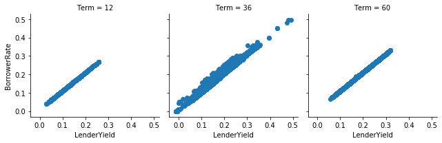

```python
g = sb.FacetGrid(data = loans, col = 'Term', height = 3,
                margin_titles = True)
g.map(plt.scatter, 'LenderYield', 'BorrowerRate');
```

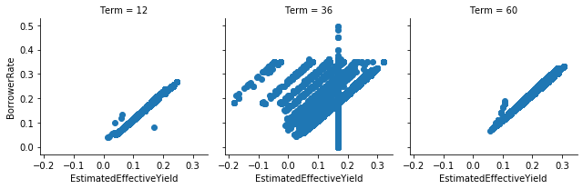

```python
g = sb.FacetGrid(data = loans, col = 'Term', height = 3,
                margin_titles = True)
g.map(plt.scatter, 'EstimatedEffectiveYield', 'BorrowerRate');
```

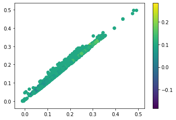

```python
plt.scatter(data = loans, x = 'LenderYield', y = 'BorrowerRate', c = 'EstimatedReturn')
plt.colorbar()
```

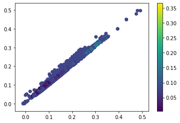

```python
plt.scatter(data = loans, x = 'LenderYield', y = 'BorrowerRate', c = 'EstimatedLoss')
plt.colorbar()
```

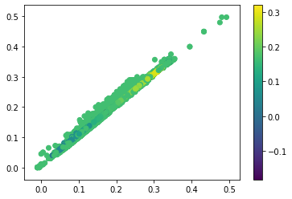

```python
plt.scatter(data = loans, x = 'LenderYield', y = 'BorrowerRate', c = 'EstimatedEffectiveYield')
plt.colorbar()
```

### Talk about some of the relationships you observed in this part of the investigation. Were there features that strengthened each other in terms of looking at your feature(s) of interest?

> The positive correlation maintains accross all the terms between the LenderYield and BorrowerRate.

### Were there any interesting or surprising interactions between features?

> Higher EstimatedffectiveYield is common with the positive correlation between the LenderYield and BorrowerRate. The same applies to EstimatedReturn.

> EstimatedLoss is less common with strong correlation between LenderYield and BorrowerRate